# DFT whole proteome analysis

Alistair Bailey

1 October 2018

## Overview

Whole proteome analysis of Salem, DFT1 and DFT2. Three replicates of whole cell lysates were run in Monash using a Thermo Q Exactive mass spectrometer.

These data were originally processed using MaxQuant using the NCBI database to identify the proteins and quantify their abundance. However, as the rest of the Tasmanian Devil project is based on the Ensembl database, the data have been processed using Peaks and the Ensembl derived custom database.

## Mapping the annotations

Creating a set of mapped annotations containing gene identifiers, protein identifiers, descriptions, contig sequences and corresponding mapped chromosomes is a multi-step process.

First we download the refseq data collection, the refseq gene assembly report, and the ensembl genome annotation file.

Next we import the ensembl genome annotation file (GTF) and extract the contig sequence names, sequence positions, gene names, and ensembl gene and protein identifiers.

We then import the refseq proteome that contains the amino acid sequences, refseq protein identifiers and protein descriptions.

Using the refseq identifiers extracted from the refseq proteome we search the ensembl biomart database and download matching ensembl gene and protein identifiers as well as the external gene name and contig sequence names.

The final piece of information required is the refseq assembly report containing the contig sequence identifiers and the mapped chromosome identifiers.

Then these data are merged in the following way:

- Join the ensembl annotation report to the biomart results according to contig identifiers
- Join the resulting table to the refseq proteins and descriptions
- Join the reuslting table to the refseq report containing chromosome identifications
- Keep only the rows with unique ensembl gene identifiers

The final table contains mapped annotations for 18,788 ensembl genes. There are many missing values for external gene names, refseq proteins and descriptions. There is no mapped Y chromosome for the Tasmanian Devil.

```
## Observations: 18,788
## Variables: 10
## $ seqnames           <chr> "GL849905.1", "GL849905.1", "GL849905.1", "...
## $ start              <int> 826885, 1831783, 1978828, 2070941, 2108084,...
## $ end                <int> 827847, 1831902, 1979044, 2070986, 2108129,...
## $ ensembl_gene_id    <chr> "ENSSHAG00000011277", "ENSSHAG00000015543",...
## $ name               <chr> NA, "ATP11B", "DCUN1D1", NA, NA, NA, NA, NA...
## $ ensembl_peptide_id <chr> "ENSSHAP00000013191", "ENSSHAP00000018311",...
## $ IDs                <chr> NA, NA, NA, NA, NA, NA, NA, NA, NA, NA, NA,...
## $ ID                 <chr> NA, NA, NA, NA, NA, NA, NA, NA, NA, NA, NA,...
## $ description        <chr> NA, NA, NA, NA, NA, NA, NA, NA, NA, NA, NA,...
## $ chr                <chr> "3", "3", "3", "3", "3", "3", "3", "3", "3"...
```

## Load the proteome data and annotate

Loading the label free quantified Peaks data and then annotating them yields 4532 proteins across DFT1, DFT2 and Salem.

## Create a summarized experiment for differential expression analysis

Using the unique ensembl protein ids, experiment replicate identifier and corresponding intensity measurement,we create a summarized experiment object.

```
## class: SummarizedExperiment
## dim: 4532 9
## metadata(0):
## assays(1): ''
## rownames(4532): ENSSHAP00000017167.1 ENSSHAP00000017373.1 ...
##   ENSSHAP00000015694.1 ENSSHAP00000012820.1
## rowData names(11): name ensembl_peptide_id ... description chr
## colnames(9): DFT1_1 DFT1_2 ... SALEM_2 SALEM_3
## colData names(4): label ID condition replicate
```

## Missing values

Plotting the number of overlapping identifications shows that most quantified proteins have been identified in all samples.

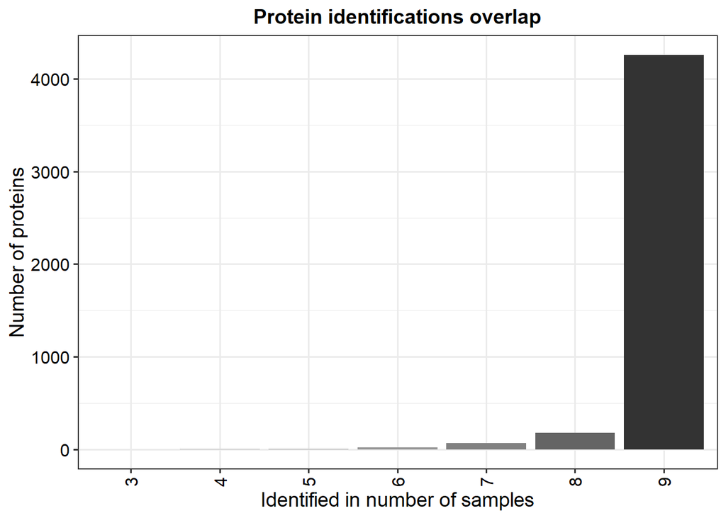

Filtering for proteins that are identified in all replicates in at least one condition yields 4527 of the initial 4532 proteins.

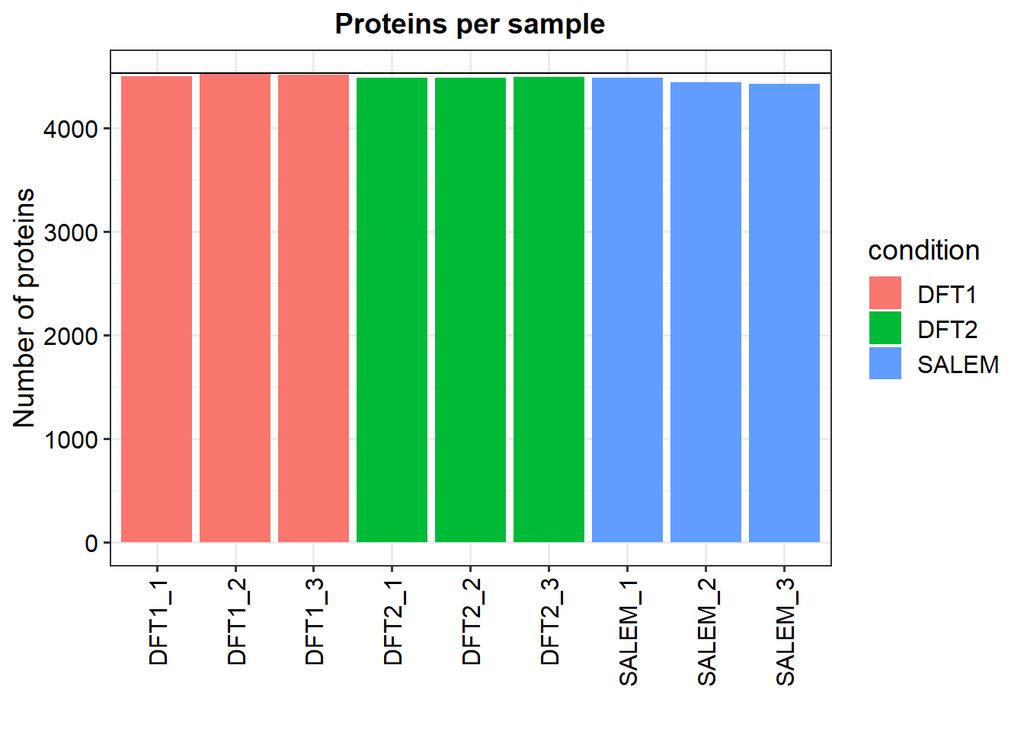

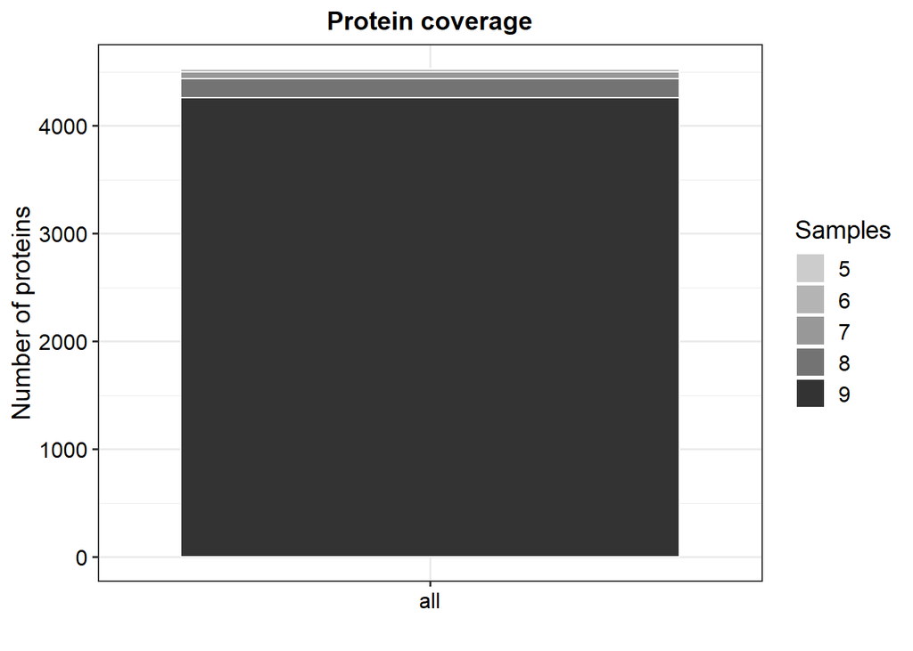

## Normalize the data

Next we normalise the data and compare it to the intial data. This indicates that Salem had the greatest variability between replicates. There are also a few outliers in all the replicates.

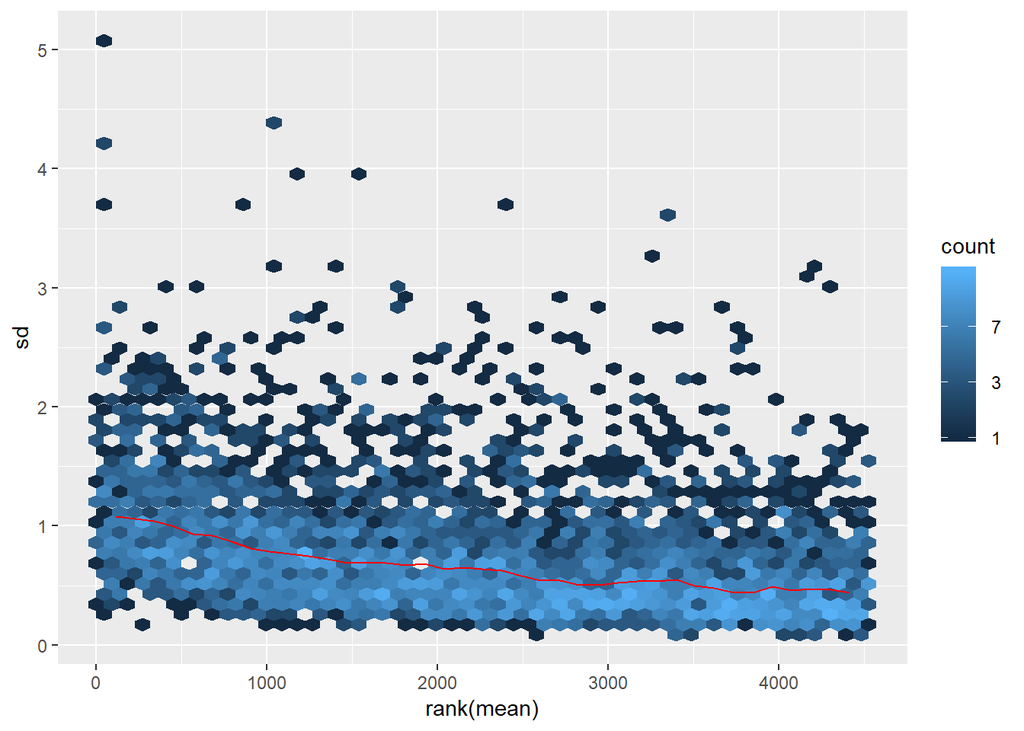

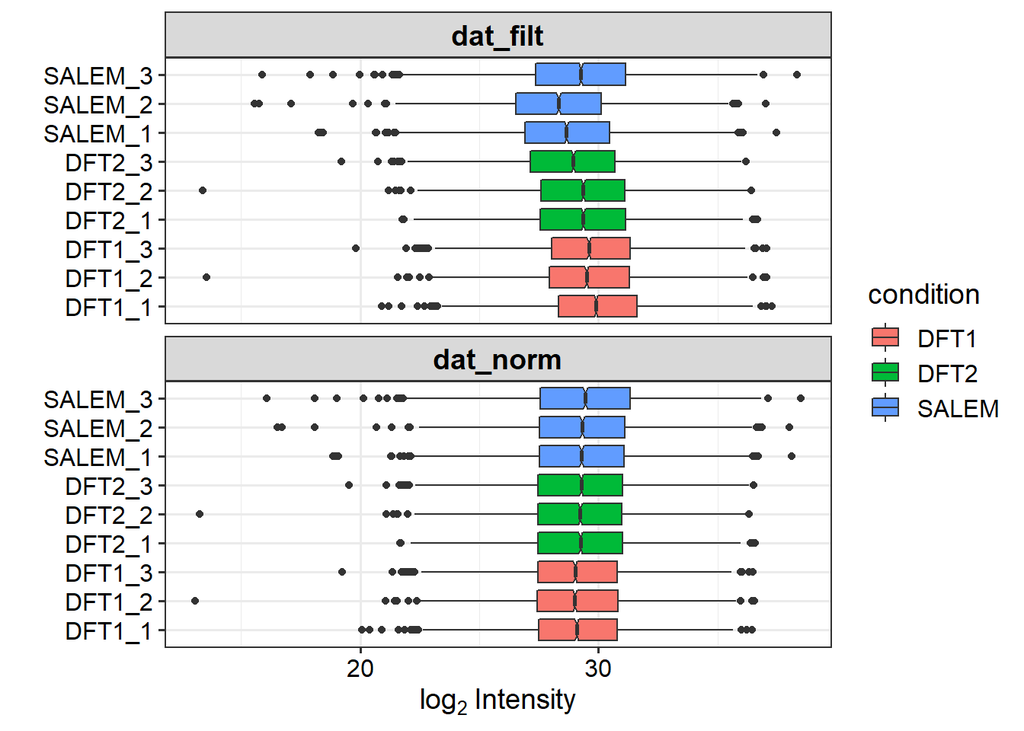

## Impute the missing values

Plotting the missing values indicates that Salem has greatest number of missing values, and that missing values have on average lower intensity values suggesting they are missing due to low abundance and not at random.

Hence we use a ‘missing not at random’ approach to imputation using the `MinProb` method to yeild values for all 4527 protein in all replicates.

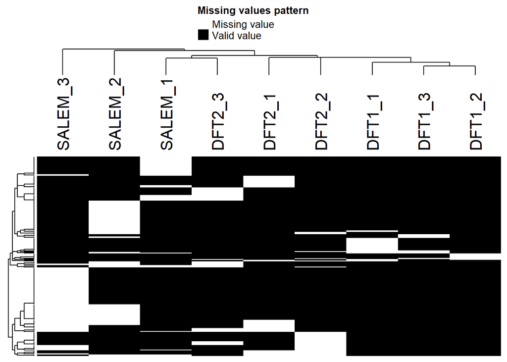

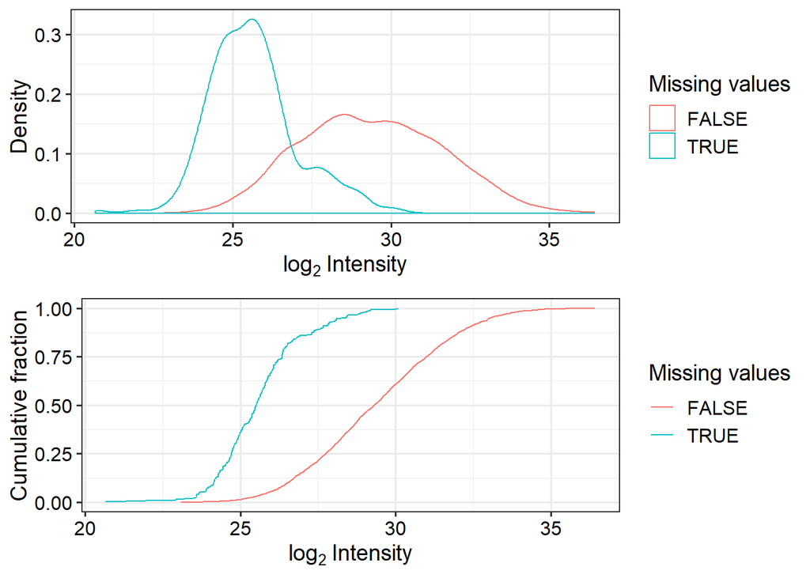

```
## [1] 0.6580703
```

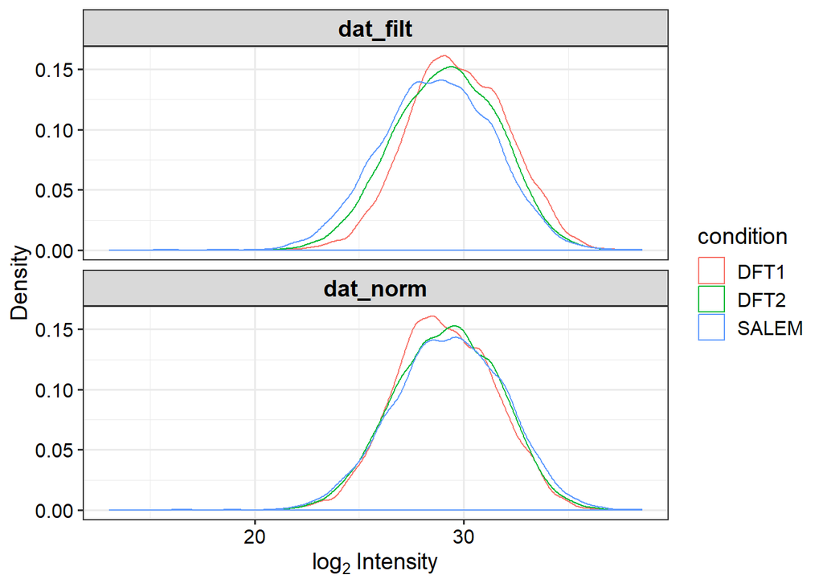

## Differential enrichment

Test all conditions against each other using the imputed data, and then filter the output at a significance level of log2 fold change of 2 and adjusted p-value of 0.05.

```
## Tested contrasts: DFT1_vs_DFT2, DFT1_vs_SALEM, DFT2_vs_SALEM
```

### PCA plot of replicates and cell lines

Using PCA we can check for replication quality. It confirms the observation of the greatest variability between replicates occurred with Salem, and that each cell line groups together.

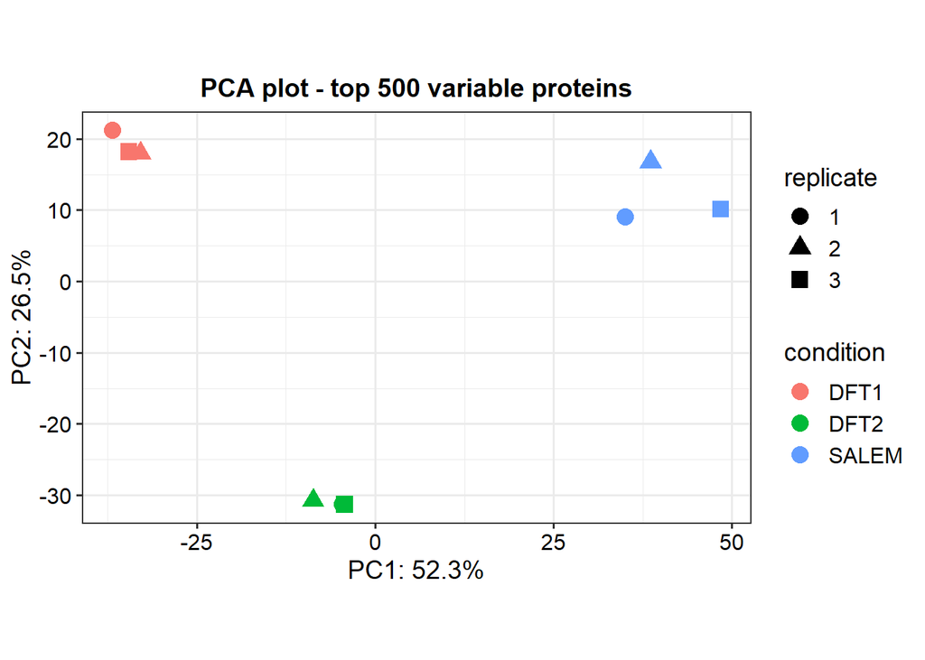

### Correlation between replicates and cell lines

A correlation heatmap indicates that DFT1 and DFT2 are more similar to each other than to Salem.

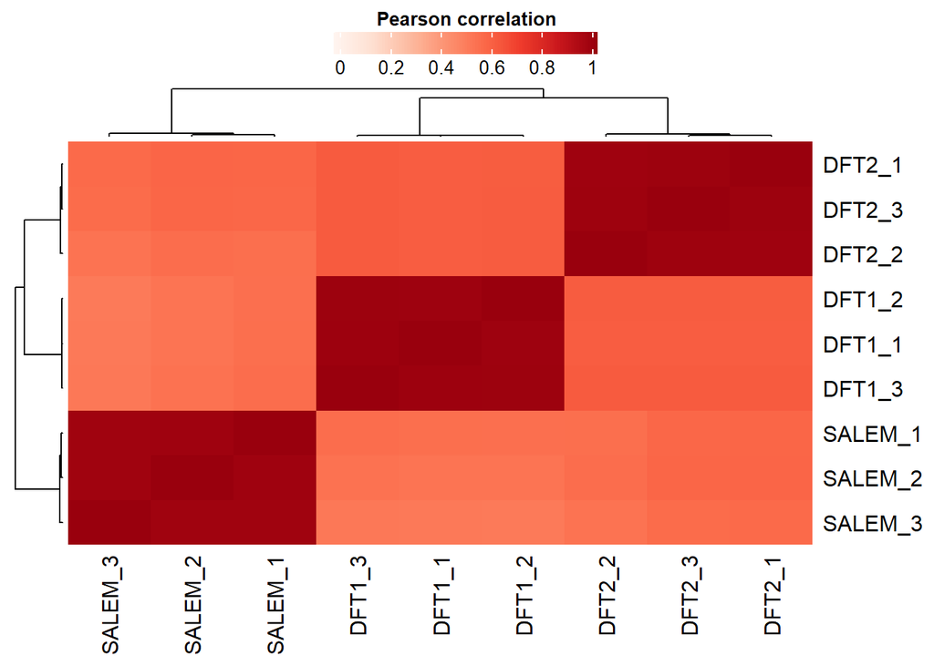

### Heatmaps

From the tutorial:

“This heatmap representation gives an overview of all significant proteins (rows) in all samples (columns). This allows to see general trends, for example if one sample or replicate is really different compared to the others. Additionally, the clustering of samples (columns) can indicate closer related samples and clustering of proteins (rows) indicates similarly behaving proteins.”

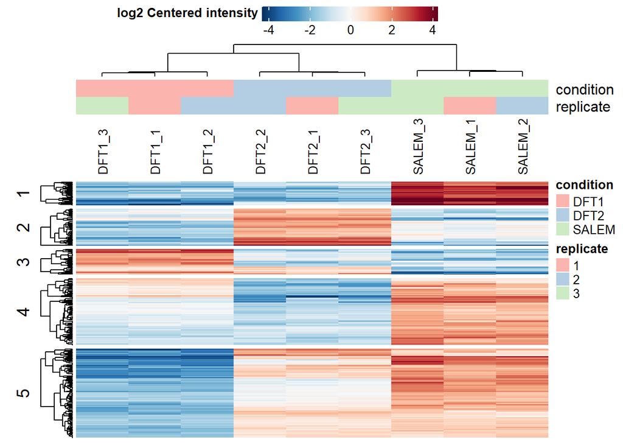

### Heatmap of significant proteins

From the tutorial:

“Alternatively, a heatmap can be plotted using the contrasts, i.e. the direct sample comparisons, as columns.”

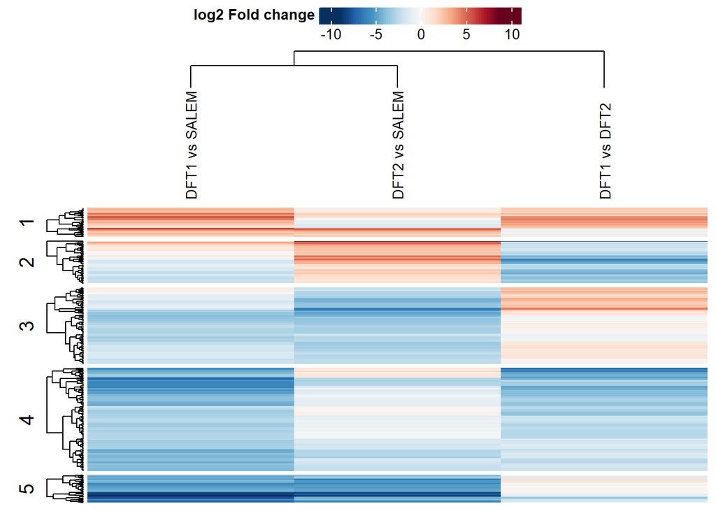

## Volcano plots

These plots combine the enrichment log-fold change and statisitcal significance (p-values).

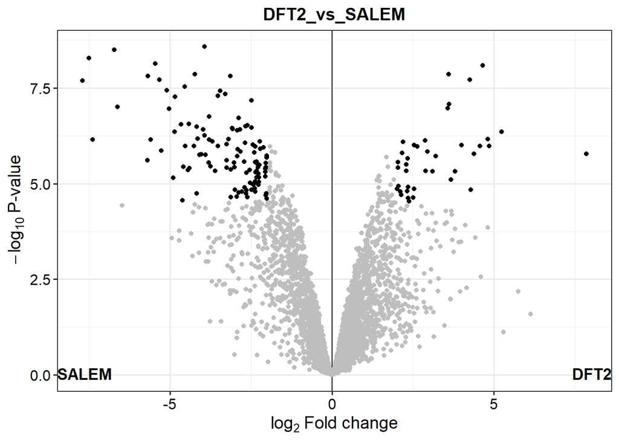

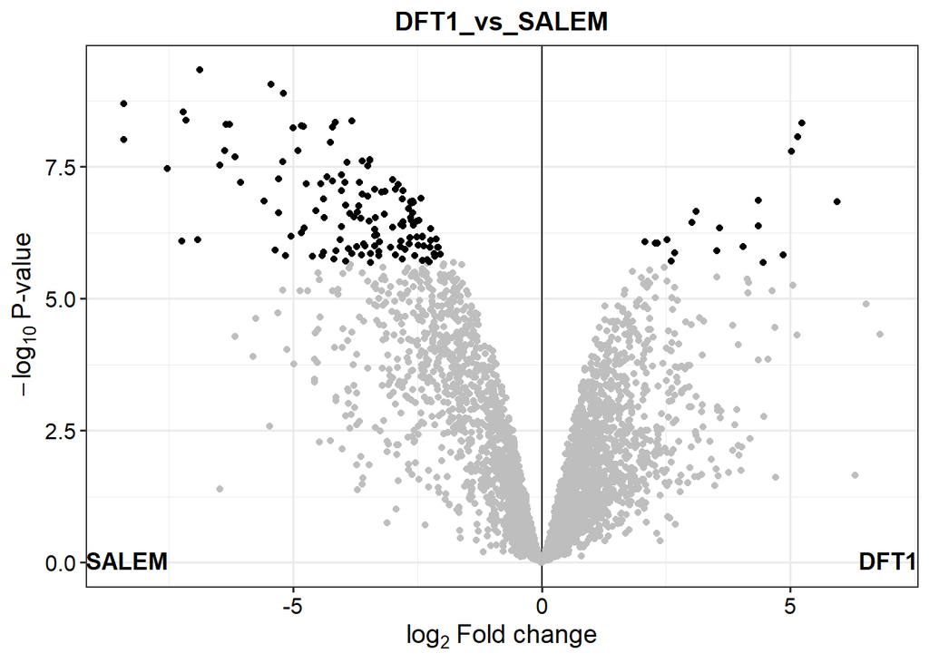

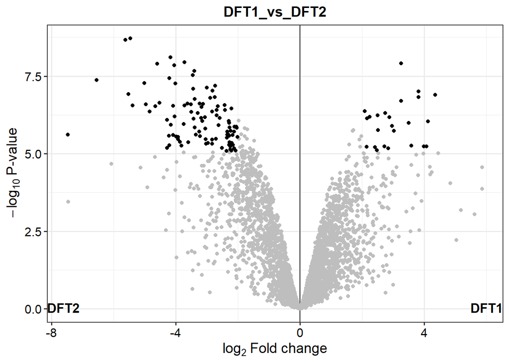

## Plot overlap between conditions

Plot the number of significantly expressed proteins per condition.

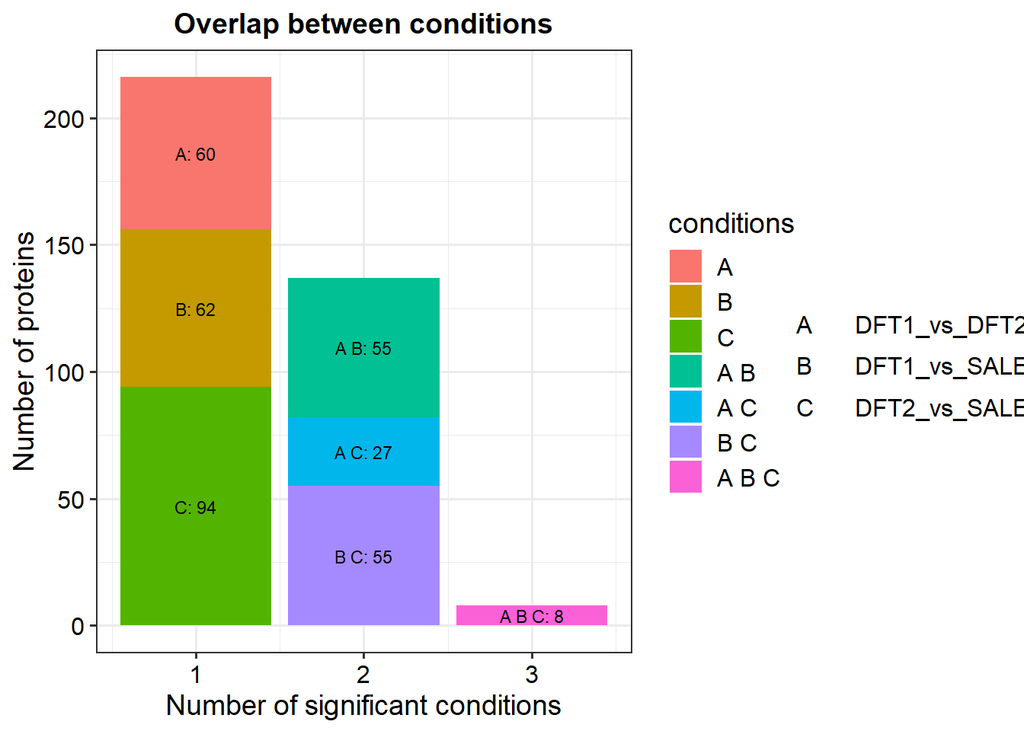

## Results

Then extract the signifcant results for each condition.

How many missing gene ids to map for each condition? There are 177 missing gene ids across all conditions.

|  | dft2_vs_salem_missing | dft1_vs_salem_missing | dft1_vs_dft2_missing |
| --- | --- | --- | --- |
| 1 | 77 | 80 | 65 |

## Write spreadsheets

Write the significantly enriched proteins per condition to spreadsheets for manual curation.